# Practical Machine Learning Project - Quality of Weight Lifting Exercise

Milind Kulkarni

Sunday, May 01, 2016

## BACKGROUND

Using devices such as Jawbone Up, Nike FuelBand, and Fitbit it is now possible to collect a large amount of data about personal activity relatively inexpensively. These type of devices are part of the quantified self movement – a group of enthusiasts who take measurements about themselves regularly to improve their health, to find patterns in their behavior, or because they are tech geeks. One thing that people regularly do is quantify how much of a particular activity they do, but they rarely quantify how well they do it. In this project, your goal will be to use data from accelerometers on the belt, forearm, arm, and dumbell of 6 participants. They were asked to perform barbell lifts correctly and incorrectly in 5 different ways. More information is available from the website here: http://groupware.les.inf.puc-rio.br/har (see the section on the Weight Lifting Exercise Dataset).

## DATA

#### Load required libraries

```r
library(caret)
library(randomForest)
library(ggthemes)
library(gridExtra)
```

```r
library(ggplot2)
library(grid)
library(e1071)
```

#### Load the data

```r
rm(list = ls())
if (!file.exists("pml-training.csv")) {
  download.file("http://d396qusza40orc.cloudfront.net/predmachlearn/pml-training.csv", destfile = "pml-training.csv")
}
if (!file.exists("pml-testing.csv")) {
  download.file("http://d396qusza40orc.cloudfront.net/predmachlearn/pml-testing.csv", destfile = "pml-testing.csv")
}
train <- read.csv("pml-training.csv", sep = ",", na.strings = c("", "NA"))
```

#### Explore and transform the data

Let’s explore the data for useful variables and any missing values.

```r
str(train)
```

[output not shown]

The train dataset includes 160 comumns and 19622 rows. Many columns include NA, so let’s remove these from the dataset. In addition, let’s also remove the columns unrelated to the sensor movements. This results in a dataset with 53 variables.

```r
train_used <- train[,c(8:11,37:49,60:68,84:86,102,113:124,140,151:160)]
```

Let’s explore the data further with density plot made of a selection of the data.

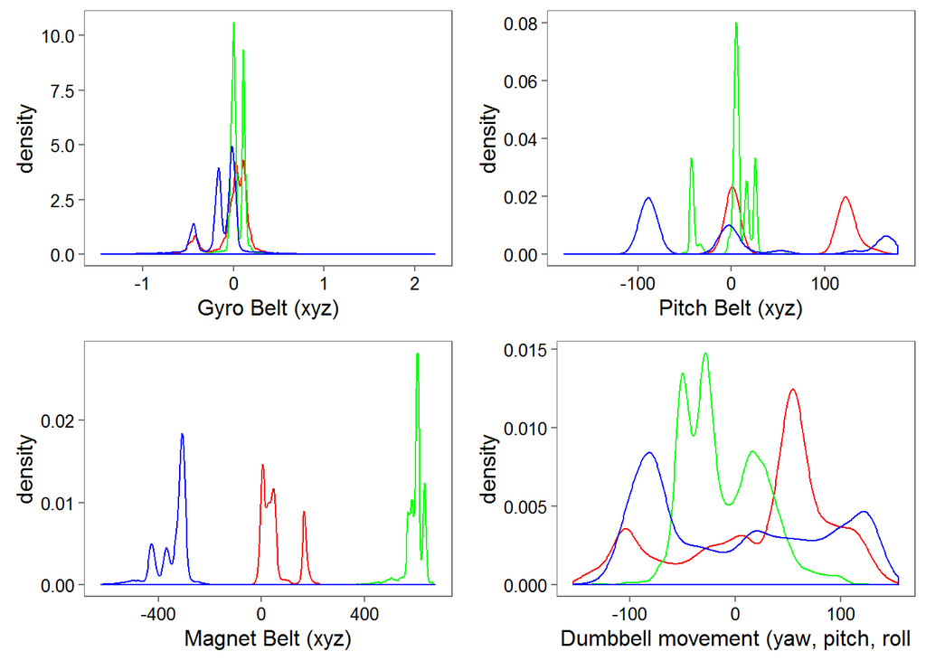

```r
Plot1 <- ggplot() + geom_density(aes(x=gyros_belt_x), colour="red", data = train_used) + geom_density(aes(x=gyros_belt_y), colour="green", data = train_used) + geom_density(aes(x=gyros_belt_z), colour="blue", data = train_used) + theme_few() + xlab("Gyro Belt (xyz)")

Plot2 <- ggplot() + geom_density(aes(x=roll_belt), colour="red", data = train_used) + geom_density(aes(x=pitch_belt), colour="green", data = train_used) + geom_density(aes(x=yaw_belt), colour="blue", data = train_used) + theme_few() + xlab("Pitch Belt (xyz)")

Plot3 <- ggplot() + geom_density(aes(x=magnet_belt_x), colour="red", data = train_used) + geom_density(aes(x=magnet_belt_y), colour="green", data = train_used) + geom_density(aes(x=magnet_belt_z), colour="blue", data = train_used) + theme_few() + xlab("Magnet Belt (xyz)")

Plot4 <- ggplot() + geom_density(aes(x=roll_dumbbell), colour="red", data = train_used) + geom_density(aes(x=pitch_dumbbell), colour="green", data = train_used) + geom_density(aes(x=yaw_dumbbell), colour="blue", data = train_used) + theme_few() + xlab("Dumbbell movement (yaw, pitch, roll")

Dplots <- arrangeGrob(Plot1, Plot2, Plot3, Plot4, nrow=2, ncol=2)
grid.draw(Dplots)
```

#### Partition the data

Let’s partition the dataset in training and testing datasets, with 60% of the original data in the training set and 40% in the testing dataset.

```r
train_part <- createDataPartition(train_used$classe, p = 0.6, list = FALSE)
training <- train_used[train_part,]
testing <- train_used[-train_part,]
```

## Build the model

Many methods of classification were attempted, including naive Bayes, multinomial logistic regression, and support vector machines. it was determined that the Random Forest method produces the best results. In addition, pre-processing using principal component analysis was attempted however this greatly reduced the predition accuracy.

#### Random Forest Model

The below section shows the confusion matrix, the out of the bag error rate. It includes a plot of the error rate vs. number of trees.

```r
set.seed(1777)
random_forest <- randomForest(classe~., data=training, ntree=500, importance=TRUE)
random_forest
```

```
##
## Call:
##  randomForest(formula = classe ~ ., data = training, ntree = 500,      importance = TRUE)
##                Type of random forest: classification
##                      Number of trees: 500
## No. of variables tried at each split: 7
##
##         OOB estimate of  error rate: 0.75%
## Confusion matrix:
##      A    B    C    D    E class.error
## A 3344    1    1    1    1 0.001194743
## B   16 2258    5    0    0 0.009214568
## C    0   13 2032    9    0 0.010710808
## D    1    0   31 1896    2 0.017616580
## E    0    0    2    5 2158 0.003233256
```

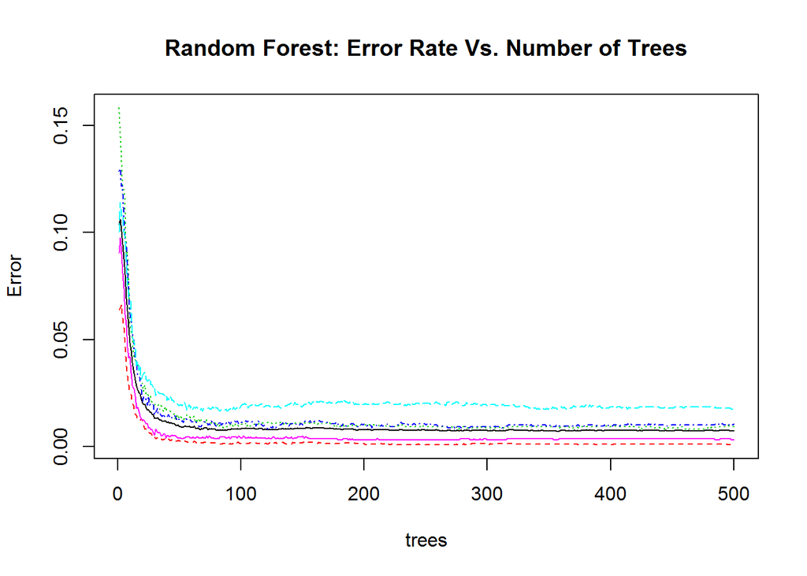

```r
plot(random_forest, main="Random Forest: Error Rate Vs. Number of Trees")
```

##### Variable Influence

Below plot shows the importance of variables in building this model. The more the accuracy of the random forest model decreases due to exclusion of a single variable the more imprtant that variable is deemed to be. Similarly, mean decrease in the Gini coefficient is a measure of how each variable contributes to the homogenity of the nodes and leaves in the resulting random forest.

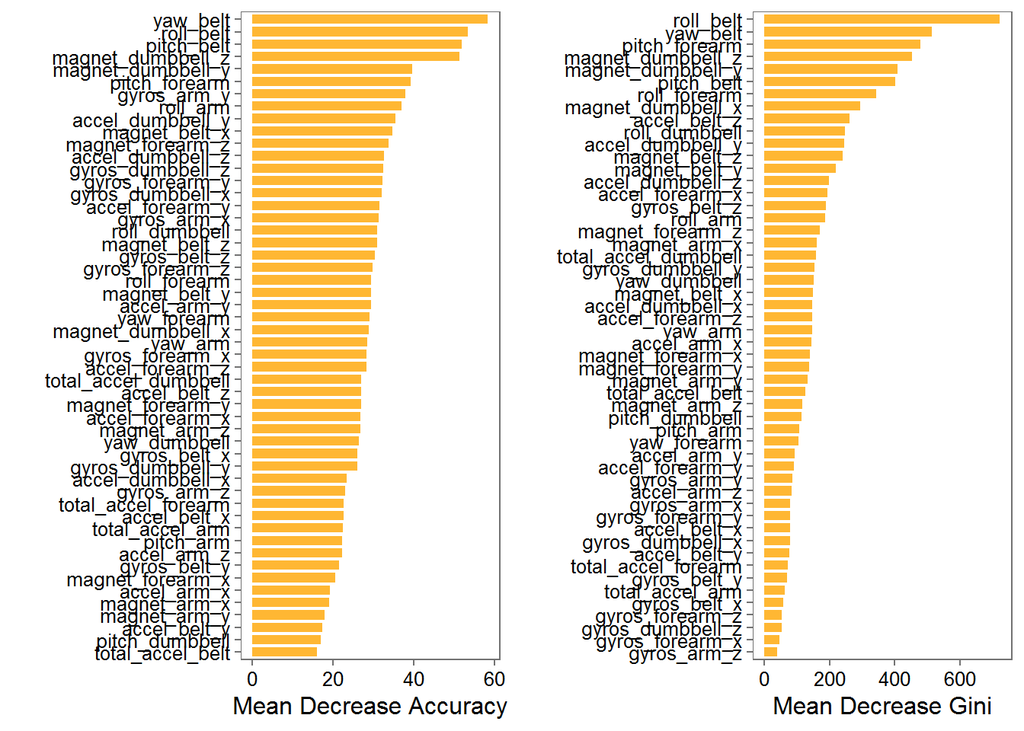

```r
imp <- importance(random_forest)
impL <- imp[,c(6,7)]
imp.ma <- as.matrix(impL)
imp.df <- data.frame(imp.ma)

write.csv(imp.df, "imp.df.csv", row.names = TRUE)
imp.df.csv <- read.csv("imp.df.csv", header = TRUE)

colnames(imp.df.csv) <-  c("Variable", "MeanDecreaseAccuracy", "MeanDecreaseGini")
imp.sort <- imp.df.csv[order(-imp.df.csv$MeanDecreaseAccuracy),]

imp.sort = transform(imp.df.csv, Variable = reorder(Variable, MeanDecreaseAccuracy))

VIP <- ggplot(data=imp.sort, aes(x=Variable, y=MeanDecreaseAccuracy)) + ylab("Mean Decrease Accuracy") + xlab("") + geom_bar(stat="identity", fill="orange", alpha=0.8, width=0.75) + coord_flip() + theme_few()

imp.sort.Gini = transform(imp.df.csv, Variable = reorder(Variable, MeanDecreaseGini))

VIP.Gini <- ggplot(data=imp.sort.Gini, aes(x=Variable, y=MeanDecreaseGini)) + ylab("Mean Decrease Gini") + xlab("") + geom_bar(stat="identity", fill="orange", alpha=0.8, width=0.75) + coord_flip() + theme_few()

VarImpPlot <- arrangeGrob(VIP, VIP.Gini, ncol=2)
grid.draw(VarImpPlot)
```

## Apply Model to Test Dataset

```r
test_predictions <- predict(random_forest, newdata=testing)
CM <- confusionMatrix(test_predictions, testing$classe)
CM
```

```
## Confusion Matrix and Statistics
##
##           Reference
## Prediction    A    B    C    D    E
##          A 2229   18    0    0    0
##          B    2 1500   11    0    0
##          C    0    0 1356    4    2
##          D    0    0    1 1282    5
##          E    1    0    0    0 1435
##
## Overall Statistics
##
##                Accuracy : 0.9944
##                  95% CI : (0.9925, 0.9959)
##     No Information Rate : 0.2845
##     P-Value [Acc > NIR] : < 2.2e-16
##
##                   Kappa : 0.9929
##  Mcnemar's Test P-Value : NA
##
## Statistics by Class:
##
##                      Class: A Class: B Class: C Class: D Class: E
## Sensitivity            0.9987   0.9881   0.9912   0.9969   0.9951
## Specificity            0.9968   0.9979   0.9991   0.9991   0.9998
## Pos Pred Value         0.9920   0.9914   0.9956   0.9953   0.9993
## Neg Pred Value         0.9995   0.9972   0.9981   0.9994   0.9989
## Prevalence             0.2845   0.1935   0.1744   0.1639   0.1838
## Detection Rate         0.2841   0.1912   0.1728   0.1634   0.1829
## Detection Prevalence   0.2864   0.1928   0.1736   0.1642   0.1830
## Balanced Accuracy      0.9977   0.9930   0.9952   0.9980   0.9975
```

## Cross Validation

Below is the code and error rates from the CV from the caret package. The model with CV leads to slightly poorer performance then the random forest.

```r
CV <- trainControl(method = "CV", number = 5, allowParallel = T, verboseIter = F)
CVModel = train(classe~., data = training, method = "rf", prox = F, trControl = CV)
CVModel
```

```
## Random Forest
##
## 11776 samples
##    52 predictor
##     5 classes: 'A', 'B', 'C', 'D', 'E'
##
## No pre-processing
## Resampling: Cross-Validated (5 fold)
## Summary of sample sizes: 9421, 9421, 9420, 9422, 9420
## Resampling results across tuning parameters:
##
##   mtry  Accuracy   Kappa
##    2    0.9878562  0.9846374
##   27    0.9874320  0.9841017
##   52    0.9802142  0.9749660
##
## Accuracy was used to select the optimal model using  the largest value.
## The final value used for the model was mtry = 2.
```

```r
predsCVModel <- predict(CVModel, newdata = testing)

confMatrix <- confusionMatrix(predsCVModel, testing$classe)
confMatrix
```

```
## Confusion Matrix and Statistics
##
##           Reference
## Prediction    A    B    C    D    E
##          A 2229   12    0    0    0
##          B    2 1504   12    0    0
##          C    0    2 1351   13    1
##          D    0    0    5 1273    5
##          E    1    0    0    0 1436
##
## Overall Statistics
##
##                Accuracy : 0.9932
##                  95% CI : (0.9912, 0.9949)
##     No Information Rate : 0.2845
##     P-Value [Acc > NIR] : < 2.2e-16
##
##                   Kappa : 0.9915
##  Mcnemar's Test P-Value : NA
##
## Statistics by Class:
##
##                      Class: A Class: B Class: C Class: D Class: E
## Sensitivity            0.9987   0.9908   0.9876   0.9899   0.9958
## Specificity            0.9979   0.9978   0.9975   0.9985   0.9998
## Pos Pred Value         0.9946   0.9908   0.9883   0.9922   0.9993
## Neg Pred Value         0.9995   0.9978   0.9974   0.9980   0.9991
## Prevalence             0.2845   0.1935   0.1744   0.1639   0.1838
## Detection Rate         0.2841   0.1917   0.1722   0.1622   0.1830
## Detection Prevalence   0.2856   0.1935   0.1742   0.1635   0.1832
## Balanced Accuracy      0.9983   0.9943   0.9926   0.9942   0.9978
```